# ** Statistics for Big Data**

## *Final Assignment*

### Alex Karvouniaris

At first, we read the data in a simple way just to extract the first row that contains useful information.

```r
library(readxl)
my_data <- read_excel("C:/Users/karvo/Desktop/aueb/statistics for big data/Project/genomes.xls")
head(my_data)
```

| NA | NA.1 | Sample 1,>5 yr survival(150 months) age 43 erp yes | Sample 2,>5 yr survival(77 months) age 44 erp yes | Sample 3,>5 yr survival(128 months) age 41 erp no | Sample 4,>5 yr survival(156 months) age 41 erp yes | Sample 5,>5 yr survival(144 months) age 48 erp yes | Sample 6,>5 yr survival(134 months) age 49 erp yes | Sample 7,>5 yr survival(122 months) age 46 erp no | Sample 8,>5 yr survival(106 months) age 48 erp no | ... | Sample 69, <5 yr survival(25 months) age 41 erp yes | Sample 70, <5 yr survival(32 months) age 38 erp yes | Sample 71, <5 yr survival(24 months) age 48 erp no | Sample 72, <5 yr survival(36 months) age 39 erp yes | Sample 73, <5 yr survival(26 months) age 50 erp no | Sample 75, <5 yr survival(27 months) age 52 erp no | Sample 76, <5 yr survival(26 months) age 52 erp no | Sample 77, <5 yr survival(24 months) age 51 erp no | Sample 78, <5 yr survival(44 months) age 54 erp yes | Sample 79, <5 yr survival(28 months) age 53 erp no |
| --- | --- | --- | --- | --- | --- | --- | --- | --- | --- | --- | --- | --- | --- | --- | --- | --- | --- | --- | --- | --- |
| Systematic name | Gene name | NA | NA | NA | NA | NA | NA | NA | NA | ... | NA | NA | NA | NA | NA | NA | NA | NA | NA | NA |
| Contig45645_RC | NA | -0.048000 | -0.243000 | 0.081000 | -0.215000 | -0.018000 | 0.071000 | 0.182000 | -0.343000 | ... | 0.132000 | 0.286000 | -0.165000 | -0.212000 | 0.840000 | 0.036000 | -0.261000 | 0.186000 | -0.288000 | -0.454000 |
| Contig44916_RC | NA | -0.005000 | -0.090000 | -0.035000 | -0.207000 | 0.370000 | 0.055000 | 0.077000 | 0.302000 | ... | 0.012000 | 0.141000 | 0.154000 | -0.010000 | 0.040000 | -0.015000 | 0.039000 | -0.102000 | 0.069000 | 0.086000 |
| D25272 | NA | 0.102000 | -0.152000 | 0.409000 | -0.158000 | 0.702000 | -0.010000 | 0.059000 | 0.169000 | ... | -0.017000 | 0.338000 | 0.102000 | 0.013000 | 0.117000 | 0.136000 | 0.001000 | -0.075000 | 0.023000 | 0.049000 |
| J00129 | FGB | -0.448000 | -0.480000 | -0.568000 | -0.819000 | -0.112000 | -0.391000 | -0.624000 | -0.528000 | ... | -0.853000 | -0.352000 | -0.601000 | -0.511000 | -0.446000 | -0.569000 | 1.206000 | -0.734000 | 0.128000 | -0.560000 |
| Contig29982_RC | NA | -0.296000 | -0.512000 | -0.411000 | -0.267000 | -0.670000 | -0.310000 | -0.120000 | -0.447000 | ... | -0.589000 | 0.088000 | -0.177000 | -0.207000 | 1.312000 | -0.146000 | -0.353000 | -0.493000 | -0.883000 | -0.454000 |

```r
aux_data<-names(my_data)
aux_data<-aux_data[3:length(aux_data)]
head(aux_data)
```

1. 'Sample 1,>5 yr survival(150 months) age 43 erp yes'

2. 'Sample 2,>5 yr survival(77 months) age 44 erp yes'

3. 'Sample 3,>5 yr survival(128 months) age 41 erp no'

4. 'Sample 4,>5 yr survival(156 months) age 41 erp yes'

5. 'Sample 5,>5 yr survival(144 months) age 48 erp yes'

6. 'Sample 6,>5 yr survival(134 months) age 49 erp yes'

## We start formulating the dataset for use, omitting this time the 1st row

```r
options(warn=-1)
my_data <- read_excel("C:/Users/karvo/Desktop/aueb/statistics for big data/Project/genomes.xls",
                      col_types=c('text','text',rep('numeric',78)),skip=1,na="NaN")
options(warn=1)
my_data<-my_data[,-2]
head(my_data)
```

| Systematic name | NA | NA.1 | NA.2 | NA.3 | NA.4 | NA.5 | NA.6 | NA.7 | NA.8 | ... | .24 | .25 | .26 | .27 | .28 | .29 | .30 | .31 | .32 | .33 |
| --- | --- | --- | --- | --- | --- | --- | --- | --- | --- | --- | --- | --- | --- | --- | --- | --- | --- | --- | --- | --- |
| Contig45645_RC | -0.048 | -0.243 | 0.081 | -0.215 | -0.018 | 0.071 | 0.182 | -0.343 | -0.134 | ... | 0.132 | 0.286 | -0.165 | -0.212 | 0.840 | 0.036 | -0.261 | 0.186 | -0.288 | -0.454 |
| Contig44916_RC | -0.005 | -0.090 | -0.035 | -0.207 | 0.370 | 0.055 | 0.077 | 0.302 | 0.051 | ... | 0.012 | 0.141 | 0.154 | -0.010 | 0.040 | -0.015 | 0.039 | -0.102 | 0.069 | 0.086 |
| D25272 | 0.102 | -0.152 | 0.409 | -0.158 | 0.702 | -0.010 | 0.059 | 0.169 | -0.007 | ... | -0.017 | 0.338 | 0.102 | 0.013 | 0.117 | 0.136 | 0.001 | -0.075 | 0.023 | 0.049 |
| J00129 | -0.448 | -0.480 | -0.568 | -0.819 | -0.112 | -0.391 | -0.624 | -0.528 | -0.811 | ... | -0.853 | -0.352 | -0.601 | -0.511 | -0.446 | -0.569 | 1.206 | -0.734 | 0.128 | -0.560 |
| Contig29982_RC | -0.296 | -0.512 | -0.411 | -0.267 | -0.670 | -0.310 | -0.120 | -0.447 | -0.536 | ... | -0.589 | 0.088 | -0.177 | -0.207 | 1.312 | -0.146 | -0.353 | -0.493 | -0.883 | -0.454 |
| Contig26811 | 0.055 | -0.189 | 1.339 | 0.229 | -0.111 | 0.157 | 0.120 | 0.283 | -0.112 | ... | -0.073 | 0.277 | 0.101 | 0.041 | 0.183 | 0.021 | -0.251 | 0.004 | -0.309 | 0.016 |

```r
sum(is.na(my_data))
```

36458

In this step, we used an auxilliary vector to help us remove the genes that had value NA for every patient. This is the safest choice we could take. If we had chosen to remove the genes that had at least one NA, we would end up throwing half genes away and severing our information a lot more.

```r
my_data<-(as.matrix(my_data))
aux<-rep(0,24481)
for (i in 1:dim(my_data)[1]){
  aux[i]<-sum(is.na(my_data[i,]))
}
my_data<-t(my_data[aux!=78,])
head(my_data)
```

| Systematic name | Contig45645_RC | Contig44916_RC | D25272 | J00129 | Contig29982_RC | Contig26811 | D25274 | Contig36292 | Contig42854 | Contig34839 | ... | NM_000895 | NM_000898 | NM_000899 | Contig20164_RC | Contig8985_RC | Contig36062_RC | Contig35333_RC | Contig62037_RC | AF067420 | Contig15167_RC |
| --- | --- | --- | --- | --- | --- | --- | --- | --- | --- | --- | --- | --- | --- | --- | --- | --- | --- | --- | --- | --- | --- |
| NA | -0.048 | -0.005 | 0.102 | -0.448 | -0.296 | 0.055 | -0.147 | 0.085 | -0.100 | 0.081 | ... | 0.002 | -0.508 | 0.032 | 0.168 | 0.062 | -0.047 | 0.118 | 0.290 | 0.031 | 0.180 |
| NA.1 | -0.243 | -0.090 | -0.152 | -0.480 | -0.512 | -0.189 | 0.108 | -0.105 | -0.031 | -0.105 | ... | 0.049 | 0.265 | 0.126 | 0.088 | 0.096 | -0.084 | 0.010 | -0.169 | -0.378 | 0.058 |
| NA.2 | 0.081 | -0.035 | 0.409 | -0.568 | -0.411 | 1.339 | 0.011 | 0.792 | -0.398 | 0.336 | ... | 0.275 | 0.499 | 0.205 | 0.254 | 0.001 | 0.063 | 0.210 | 0.299 | -0.356 | 0.153 |
| NA.3 | -0.215 | -0.207 | -0.158 | -0.819 | -0.267 | 0.229 | 0.059 | -0.018 | 0.023 | -0.064 | ... | -0.028 | 0.620 | 0.154 | 0.014 | 0.033 | -0.175 | -0.070 | -0.049 | -0.394 | 0.051 |
| NA.4 | -0.018 | 0.370 | 0.702 | -0.112 | -0.670 | -0.111 | 0.144 | 0.229 | 0.421 | -0.037 | ... | -0.093 | -0.609 | -0.039 | 0.051 | 0.070 | 0.087 | -0.140 | 0.001 | -0.036 | 0.000 |

```r
dim(my_data)
```

1. 79

2. 24188

```r
names<-my_data[1,]
my_data<-as.data.frame(my_data[-1,])
names(my_data)<-names
aux<-as.character(seq(1,78))
names<-rep('',78)
for( i in 1:78){
    names[i]<-paste('X',aux[i],sep='')
}
rownames(my_data)<-names
my_data
```

|  | Contig45645_RC | Contig44916_RC | D25272 | J00129 | Contig29982_RC | Contig26811 | D25274 | Contig36292 | Contig42854 | Contig34839 | ... | NM_000895 | NM_000898 | NM_000899 | Contig20164_RC | Contig8985_RC | Contig36062_RC | Contig35333_RC | Contig62037_RC | AF067420 | Contig15167_RC |
| --- | --- | --- | --- | --- | --- | --- | --- | --- | --- | --- | --- | --- | --- | --- | --- | --- | --- | --- | --- | --- | --- |
| X1 | -0.048 | -0.005 | 0.102 | -0.448 | -0.296 | 0.055 | -0.147 | 0.085 | -0.100 | 0.081 | ... | 0.002 | -0.508 | 0.032 | 0.168 | 0.062 | -0.047 | 0.118 | 0.290 | 0.031 | 0.180 |
| X2 | -0.243 | -0.090 | -0.152 | -0.480 | -0.512 | -0.189 | 0.108 | -0.105 | -0.031 | -0.105 | ... | 0.049 | 0.265 | 0.126 | 0.088 | 0.096 | -0.084 | 0.010 | -0.169 | -0.378 | 0.058 |
| X3 | 0.081 | -0.035 | 0.409 | -0.568 | -0.411 | 1.339 | 0.011 | 0.792 | -0.398 | 0.336 | ... | 0.275 | 0.499 | 0.205 | 0.254 | 0.001 | 0.063 | 0.210 | 0.299 | -0.356 | 0.153 |
| X4 | -0.215 | -0.207 | -0.158 | -0.819 | -0.267 | 0.229 | 0.059 | -0.018 | 0.023 | -0.064 | ... | -0.028 | 0.620 | 0.154 | 0.014 | 0.033 | -0.175 | -0.070 | -0.049 | -0.394 | 0.051 |
| X5 | -0.018 | 0.370 | 0.702 | -0.112 | -0.670 | -0.111 | 0.144 | 0.229 | 0.421 | -0.037 | ... | -0.093 | -0.609 | -0.039 | 0.051 | 0.070 | 0.087 | -0.140 | 0.001 | -0.036 | 0.000 |
| X6 | 0.071 | 0.055 | -0.010 | -0.391 | -0.310 | 0.157 | -0.135 | 0.001 | -0.060 | 0.030 | ... | 0.046 | -0.061 | 0.067 | -0.036 | -0.038 | 0.171 | -0.023 | -0.058 | 0.043 | -0.014 |
| X7 | 0.182 | 0.077 | 0.059 | -0.624 | -0.120 | 0.120 | 0.067 | 0.053 | -0.236 | 0.019 | ... | 0.096 | 0.167 | -0.105 | -0.014 | -0.118 | -0.042 | 0.002 | -0.123 | 0.546 | -0.009 |
| X8 | -0.343 | 0.302 | 0.169 | -0.528 | -0.447 | 0.283 | 0.032 | 0.167 | -0.254 | 0.213 | ... | 0.093 | 0.120 | -0.020 | -0.061 | -0.160 | -0.048 | -0.056 | 0.022 | 0.140 | -0.109 |
| X9 | -0.134 | 0.051 | -0.007 | -0.811 | -0.536 | -0.112 | -0.192 | 0.172 | -0.211 | 0.298 | ... | 0.031 | -0.762 | 0.205 | 0.227 | -0.082 | 0.119 | 0.200 | 0.281 | -0.363 | 0.070 |
| X10 | -0.320 | -0.241 | -0.206 | -0.839 | 2.000 | -2.000 | 0.034 | -0.116 | 0.147 | 0.086 | ... | -0.036 | 0.126 | 0.093 | -0.031 | -0.149 | -0.143 | -0.111 | 0.097 | -0.211 | 0.055 |
| X11 | -0.107 | 0.025 | 0.008 | -0.420 | -0.286 | 0.152 | -0.064 | 0.230 | -0.090 | 0.054 | ... | 0.009 | -1.069 | 0.145 | -0.109 | -0.019 | -0.161 | -0.124 | -0.118 | -0.081 | -0.060 |
| X12 | -1.657 | -0.376 | -0.349 | -0.686 | -0.333 | 0.697 | -0.110 | -0.002 | -0.295 | 0.193 | ... | -0.336 | -0.166 | -0.302 | -0.127 | -0.216 | -0.285 | -0.155 | -0.386 | -0.144 | -0.177 |
| X13 | 0.365 | 0.349 | 0.312 | -0.299 | -0.137 | 0.408 | 0.010 | 0.380 | -0.214 | 0.289 | ... | -0.019 | -0.527 | -0.112 | -0.096 | -0.144 | -0.098 | 0.032 | -0.088 | 0.450 | -0.058 |
| X14 | 0.046 | 0.156 | 0.045 | -0.416 | -0.633 | -0.169 | 0.023 | -0.085 | -0.088 | -0.006 | ... | 0.054 | -0.425 | -0.119 | -0.006 | 0.100 | -0.055 | -0.070 | -0.026 | -0.062 | 0.076 |
| X15 | -0.028 | -0.069 | -0.152 | -0.903 | -0.638 | -0.172 | 0.136 | 0.037 | 0.173 | 0.120 | ... | -0.222 | 0.441 | 0.020 | -0.018 | 0.160 | -0.263 | 0.009 | -0.105 | -0.582 | 0.103 |
| X16 | -0.273 | 0.426 | 0.119 | -0.605 | -0.344 | 0.217 | -0.116 | 0.040 | -0.052 | 0.044 | ... | -0.071 | -0.623 | 0.046 | -0.053 | -0.165 | 0.116 | -0.065 | -0.012 | -0.343 | -0.404 |
| X17 | 0.719 | -0.187 | -0.759 | -0.721 | -0.527 | -0.130 | -0.016 | -0.342 | -0.332 | -0.178 | ... | 0.013 | 0.109 | -0.123 | 0.412 | -0.109 | 0.048 | -0.048 | 0.390 | 0.023 | 0.044 |
| X18 | -0.046 | -0.727 | -0.943 | -1.134 | -0.168 | -0.221 | 0.111 | 0.204 | -0.168 | 0.106 | ... | 0.153 | 0.307 | -0.020 | 0.031 | 0.022 | -0.228 | -0.128 | -0.154 | -0.232 | -0.077 |
| X19 | 0.385 | 0.562 | 0.364 | -1.029 | -0.260 | 0.443 | -0.091 | 1.469 | -0.281 | 1.429 | ... | -0.026 | -0.578 | 0.102 | 0.145 | 0.092 | 0.127 | 0.154 | 0.488 | 0.070 | 0.278 |
| X20 | -0.089 | 0.048 | 0.030 | -0.385 | -0.347 | 0.124 | 0.041 | 0.098 | -0.395 | 0.084 | ... | 0.145 | -0.248 | 0.154 | -0.065 | 0.033 | -0.099 | 0.337 | -0.115 | -0.290 | -0.120 |
| X21 | 0.438 | 0.232 | 0.427 | -0.800 | -0.556 | 0.091 | -0.003 | 0.283 | -0.442 | 0.321 | ... | 0.078 | -0.399 | -0.039 | -0.021 | 0.034 | -0.100 | 0.040 | 0.361 | 0.765 | 2.000 |
| X22 | -0.038 | -0.153 | -0.156 | -0.755 | -0.382 | -0.182 | 0.059 | -0.016 | 0.207 | -0.080 | ... | 0.018 | 0.399 | 0.070 | 0.096 | 0.207 | -0.211 | -0.044 | -0.176 | -0.447 | -0.058 |
| X23 | 0.202 | 0.113 | -0.285 | -0.767 | 0.027 | 0.026 | -0.051 | -0.089 | -0.134 | -0.160 | ... | 0.116 | 0.025 | 0.205 | -0.081 | 0.007 | -0.098 | -0.140 | 0.014 | -0.201 | -0.030 |
| X24 | -0.204 | 0.085 | 0.079 | -0.945 | -0.542 | -0.037 | 0.168 | 0.195 | -0.189 | 0.154 | ... | -0.150 | 0.637 | -0.298 | -0.199 | -0.038 | -0.128 | -0.030 | -0.396 | -0.504 | -0.025 |
| X25 | -0.277 | -0.061 | -0.194 | -1.173 | -0.887 | -0.017 | -0.135 | 0.018 | -0.058 | 0.130 | ... | -0.065 | -1.096 | -0.060 | -0.101 | -0.026 | 0.024 | -0.083 | -0.295 | -0.577 | -0.004 |
| X26 | -2.000 | -0.274 | -0.501 | -0.750 | -0.316 | -0.217 | 0.140 | -0.187 | -0.021 | -0.087 | ... | 0.090 | 0.013 | -0.121 | -0.133 | 0.014 | -0.060 | -0.002 | -0.027 | -0.057 | 0.116 |
| X27 | 0.257 | -0.041 | -0.093 | -0.474 | -0.119 | -0.071 | -0.014 | -0.043 | -0.075 | -0.086 | ... | -0.009 | 0.556 | 0.044 | -0.023 | 0.048 | -0.005 | -0.071 | -0.216 | -2.000 | -0.123 |
| X28 | 0.273 | -0.125 | -0.340 | -0.749 | 0.699 | 0.119 | 0.010 | 0.637 | -0.346 | 0.468 | ... | 0.307 | 0.229 | -0.003 | 0.287 | 0.046 | -0.160 | 0.128 | 0.438 | 0.685 | 0.201 |
| X29 | 0.177 | 0.033 | 0.010 | -0.523 | 0.134 | -0.690 | -0.202 | -0.257 | 0.024 | 0.000 | ... | -0.219 | -0.104 | 0.159 | 0.183 | -0.120 | 0.019 | 0.141 | 0.108 | 0.133 | 0.102 |
| X30 | 0.221 | 0.004 | -0.113 | -0.482 | -0.120 | 0.012 | -0.112 | -0.078 | 0.159 | 0.023 | ... | 0.004 | 0.149 | 0.047 | 0.062 | -0.056 | 0.107 | -0.101 | 0.043 | 0.527 | -0.410 |
| ... | ... | ... | ... | ... | ... | ... | ... | ... | ... | ... |  | ... | ... | ... | ... | ... | ... | ... | ... | ... | ... |
| X49 | -0.141 | 0.025 | -0.031 | -0.465 | -0.533 | -0.065 | 0.101 | -0.008 | -0.019 | 0.026 | ... | 0.132 | 0.280 | -0.088 | 0.043 | 0.207 | -0.124 | -0.041 | -0.077 | -0.432 | -0.015 |
| X50 | -0.149 | 0.068 | -0.084 | -0.557 | -0.595 | -0.062 | -0.056 | -0.009 | 0.031 | 0.187 | ... | -0.038 | -0.258 | -0.135 | -0.013 | -0.045 | -0.114 | 0.643 | -0.162 | -0.976 | -0.078 |
| X51 | -0.382 | 0.064 | 0.033 | -0.873 | -0.474 | 0.148 | -0.048 | 0.042 | 0.116 | 0.061 | ... | -0.059 | -0.286 | -0.227 | -0.012 | 0.021 | 0.190 | -0.006 | -0.219 | -0.073 | -0.077 |
| X52 | -0.210 | 0.106 | 0.191 | -0.189 | -0.309 | 0.225 | -0.022 | 0.140 | -0.152 | 0.136 | ... | 0.084 | 0.064 | -0.016 | -0.129 | -0.023 | -0.140 | -0.082 | -0.061 | 0.664 | -0.064 |
| X53 | -0.305 | 0.068 | 0.119 | 0.642 | -0.523 | 0.148 | 0.080 | 0.293 | -0.015 | 0.443 | ... | -0.242 | -1.067 | -0.042 | -0.160 | -0.126 | 0.010 | 0.057 | -1.159 | -0.183 | -0.050 |
| X54 | NA | NA | NA | -2.000 | -1.927 | 2.000 | -0.094 | NA | 0.077 | NA | ... | 0.119 | 0.162 | 0.120 | 0.873 | 0.098 | -0.130 | 0.111 | NA | -1.619 | 0.290 |
| X55 | -0.496 | -0.065 | -0.273 | -0.672 | -1.101 | -0.093 | -0.102 | 0.082 | -0.137 | 0.057 | ... | 0.192 | 1.212 | 0.220 | 0.115 | 0.044 | -0.004 | -0.043 | 0.021 | -1.098 | 0.244 |
| X56 | -0.124 | -0.157 | -0.162 | -0.739 | 0.093 | -0.166 | -0.102 | -0.023 | -0.214 | 0.033 | ... | 0.110 | 0.388 | 0.014 | -0.026 | 0.177 | -0.256 | 0.167 | -0.157 | 0.738 | -0.024 |
| X57 | -0.359 | 0.096 | 0.051 | -0.942 | -0.160 | -0.081 | -0.219 | -0.090 | -0.419 | 0.092 | ... | -0.066 | -0.464 | -0.204 | 0.027 | 0.045 | -0.141 | 0.233 | -0.222 | -0.324 | 0.184 |
| X58 | -0.038 | 0.059 | 0.063 | -0.588 | -0.345 | 0.146 | -0.031 | 0.187 | 0.167 | 0.099 | ... | -0.075 | -0.807 | 0.304 | -0.012 | 0.109 | -0.033 | -0.102 | -0.096 | -0.635 | -0.079 |
| X59 | -0.240 | -0.051 | -0.132 | -0.688 | -0.659 | -0.106 | 0.178 | 0.007 | -0.090 | 0.083 | ... | -0.130 | 0.025 | -0.075 | 0.006 | 0.105 | -0.056 | -0.071 | 0.125 | -0.912 | 0.008 |
| X60 | -0.230 | 0.061 | -0.013 | -0.573 | -0.600 | 0.113 | -0.149 | 0.016 | 0.213 | -0.036 | ... | -0.080 | 0.383 | -0.017 | 0.110 | 0.001 | 0.577 | -0.021 | 0.002 | -0.470 | 0.007 |
| X61 | 0.078 | -0.260 | -0.364 | -1.319 | -0.849 | -0.188 | 0.065 | -0.099 | -0.105 | 0.033 | ... | -0.132 | 0.570 | -0.152 | 0.068 | 0.109 | -0.143 | -0.112 | 0.183 | -0.504 | 0.014 |
| X62 | -0.180 | 0.245 | -0.162 | -0.919 | -0.704 | -0.005 | -0.070 | 0.181 | -0.203 | 0.086 | ... | -0.090 | -0.439 | 0.150 | 0.136 | 0.103 | -0.101 | 0.010 | 0.050 | -0.161 | 0.059 |
| X63 | -0.050 | 0.083 | -0.028 | -0.553 | -0.451 | 0.050 | -0.004 | 0.179 | 0.272 | -0.025 | ... | 0.068 | -0.060 | 0.290 | -0.008 | -0.036 | 0.037 | -0.102 | 0.124 | -0.692 | 0.164 |
| X64 | -0.279 | 0.054 | -0.048 | 0.786 | -0.164 | -0.139 | -0.021 | 0.052 | -0.144 | -0.047 | ... | -0.046 | -1.125 | -0.145 | -0.015 | -0.098 | 0.001 | 0.049 | -0.077 | 0.219 | -0.074 |
| X65 | -0.476 | -0.194 | -0.174 | -0.731 | -0.390 | -0.828 | 0.030 | 0.118 | -0.344 | 0.247 | ... | -0.057 | -0.197 | -0.040 | 0.021 | -0.061 | -0.175 | -0.068 | 0.201 | -0.243 | 0.003 |
| X66 | -0.419 | 0.067 | -0.248 | -0.262 | -0.418 | -0.049 | 0.051 | -0.010 | -0.171 | 0.083 | ... | 0.280 | -1.215 | 0.147 | 0.011 | -0.043 | -0.196 | -0.005 | -0.014 | -0.888 | 0.081 |
| X67 | -0.100 | 0.122 | 0.048 | -0.455 | -0.288 | -0.025 | 0.065 | -0.007 | -0.241 | 0.189 | ... | -0.132 | -0.343 | -0.108 | -0.011 | -0.125 | -0.052 | -0.058 | 0.009 | -0.438 | 0.074 |
| X68 | 0.074 | -0.047 | -0.041 | -0.509 | 0.459 | -0.093 | 0.013 | -0.178 | -0.257 | 0.045 | ... | -0.071 | -0.139 | -0.013 | -0.049 | -0.040 | 0.050 | -0.059 | -0.073 | -0.146 | -0.028 |
| X69 | 0.132 | 0.012 | -0.017 | -0.853 | -0.589 | -0.073 | 0.155 | 0.130 | -0.055 | 0.094 | ... | -0.148 | -0.536 | 0.140 | 0.029 | 0.041 | 0.497 | 0.306 | 0.174 | -0.027 | 0.077 |
| X70 | 0.286 | 0.141 | 0.338 | -0.352 | 0.088 | 0.277 | -0.116 | 0.301 | -0.115 | 0.315 | ... | -0.070 | -0.337 | 0.056 | 0.051 | 0.120 | -0.081 | 0.000 | 0.076 | -0.464 | 0.095 |
| X71 | -0.165 | 0.154 | 0.102 | -0.601 | -0.177 | 0.101 | 0.032 | 0.060 | -0.200 | 0.204 | ... | -0.380 | -0.468 | 0.353 | 0.361 | 0.019 | 0.169 | 0.223 | 0.556 | -0.844 | 0.105 |
| X72 | -0.212 | -0.010 | 0.013 | -0.511 | -0.207 | 0.041 | -0.010 | 0.130 | 0.175 | 0.021 | ... | -0.052 | -0.586 | -0.235 | -0.056 | 0.001 | 0.047 | -0.094 | -0.149 | 0.170 | -0.258 |
| X73 | 0.840 | 0.040 | 0.117 | -0.446 | 1.312 | 0.183 | 0.090 | 0.124 | -0.153 | 0.159 | ... | 0.080 | 0.252 | -0.041 | -0.019 | -0.100 | -0.006 | -0.019 | -0.075 | -0.823 | -0.131 |
| X74 | 0.036 | -0.015 | 0.136 | -0.569 | -0.146 | 0.021 | -0.147 | -0.060 | -0.265 | 0.002 | ... | -0.167 | 0.357 | -0.010 | 0.031 | -0.029 | -0.168 | 0.054 | -0.114 | 0.345 | 0.025 |
| X75 | -0.261 | 0.039 | 0.001 | 1.206 | -0.353 | -0.251 | 0.184 | -0.219 | -0.039 | -0.112 | ... | -0.264 | -1.089 | -0.041 | 0.035 | -0.054 | 0.064 | -0.028 | 0.005 | -0.326 | 0.087 |
| X76 | 0.186 | -0.102 | -0.075 | -0.734 | -0.493 | 0.004 | 0.040 | -0.333 | 0.088 | -0.014 | ... | 0.121 | 0.139 | 0.006 | 0.025 | 0.060 | 0.166 | 0.067 | -0.016 | -0.038 | 0.050 |
| X77 | -0.288 | 0.069 | 0.023 | 0.128 | -0.883 | -0.309 | 0.122 | -0.141 | 0.177 | -0.050 | ... | -0.117 | -0.455 | -0.081 | 0.008 | -0.006 | -0.007 | -0.062 | 0.022 | -0.171 | -0.011 |
| X78 | -0.454 | 0.086 | 0.049 | -0.560 | -0.454 | 0.016 | -0.093 | -0.149 | -0.145 | 0.062 | ... | -0.012 | -0.565 | -0.016 | 0.041 | -0.040 | 0.029 | -0.036 | 0.126 | -0.060 | 0.001 |

Now we want to transform the data contained in the initial first row of the dataset and use the variables as columns. The only choice that had to be taken here is that, in terms of response variable we have 2 options. We know for each patient how many months she survived and whether that duration is longer than 5 years. So we have the option to pick between binary response and survival data. In our case, we go with the binary one.

```r
library(car)
survival<-rep(' ',78)
age<-rep(0,78)
erp<-rep(' ',78)
aux<-gsub("\\Sample +.*,"," ",aux_data)
aux2<-gsub('.*age ',' ',aux_data)
aux3<-gsub('.*erp ',' ',aux_data)
for( i in 1:length(aux)){
    survival[i]<-substr(aux[i],1,2)
    if( survival[i]==' >'){
        survival[i]<-1
    }
    else survival[i]<-0
    age[i]<-substr(aux2[i],1,3)
    erp[i]<-aux3[i]

}
survival<-as.integer(survival)
age<-as.integer(age)
erp<-gsub('yes','1',erp)
erp<-gsub('no','0',erp)
erp<-gsub('missing','NA',erp)
erp<-as.integer(erp)
survival;age;erp
```

1. 1

2. 1

3. 1

4. 1

5. 1

6. 1

7. 1

8. 1

9. 1

10. 1

11. 1

12. 1

13. 1

14. 1

15. 1

16. 1

17. 1

18. 1

19. 1

20. 1

21. 1

22. 1

23. 1

24. 1

25. 1

26. 1

27. 1

28. 1

29. 1

30. 1

31. 1

32. 1

33. 1

34. 1

35. 1

36. 1

37. 1

38. 1

39. 1

40. 1

41. 1

42. 1

43. 1

44. 1

45. 0

46. 0

47. 0

48. 0

49. 0

50. 0

51. 0

52. 0

53. 0

54. 0

55. 0

56. 0

57. 0

58. 0

59. 0

60. 0

61. 0

62. 0

63. 0

64. 0

65. 0

66. 0

67. 0

68. 0

69. 0

70. 0

71. 0

72. 0

73. 0

74. 0

75. 0

76. 0

77. 0

78. 0

1. 43

2. 44

3. 41

4. 41

5. 48

6. 49

7. 46

8. 48

9. 48

10. 38

11. 37

12. 46

13. 41

14. 48

15. 46

16. 49

17. 48

18. 32

19. 48

20. 34

21. 39

22. 45

23. 41

24. 49

25. 45

26. 40

27. 45

28. 40

29. 52

30. 54

31. 52

32. 54

33. 52

34. 54

35. 54

36. 52

37. 54

38. 52

39. 46

40. 53

41. 54

42. 54

43. 54

44. 53

45. 37

46. 44

47. 43

48. 30

49. 39

50. 39

51. 41

52. 45

53. 28

54. 43

55. 41

56. 30

57. 28

58. 38

59. 44

60. 45

61. 38

62. 36

63. 37

64. 33

65. 42

66. 47

67. 41

68. 50

69. 41

70. 38

71. 48

72. 39

73. 50

74. 52

75. 52

76. 51

77. 54

78. 53

1. 1

2. 1

3. 0

4. 1

5. 1

6. 1

7. 0

8. 0

9. 1

10. 1

11. 1

12. 0

13. 1

14. 1

15. 1

16. 0

17. 1

18. 0

19. 1

20. 0

21. 1

22. 1

23. 1

24. 0

25. 1

26. 1

27. 1

28. 0

29. 1

30. 1

31. 1

32. 1

33. 0

34. 1

35. 1

36. 1

37. NA

38. 1

39. 1

40. 1

41. 1

42. 1

43. 1

44. 0

45. 1

46. 0

47. 0

48. 0

49. 0

50. 1

51. 1

52. 1

53. 0

54. 1

55. 1

56. 1

57. 0

58. 1

59. 1

60. 1

61. 1

62. 0

63. 1

64. 0

65. 0

66. 1

67. 0

68. 0

69. 1

70. 1

71. 0

72. 1

73. 0

74. 0

75. 0

76. 0

77. 1

78. 0

```r
for( i in 1:dim(my_data)[2]){
    my_data[,i] <- as.numeric(as.character(my_data[,i]))}
```

```r
my_data$age<-age
my_data$erp<-erp
my_data$survival<-survival
my_data
```

|  | Contig45645_RC | Contig44916_RC | D25272 | J00129 | Contig29982_RC | Contig26811 | D25274 | Contig36292 | Contig42854 | Contig34839 | ... | Contig20164_RC | Contig8985_RC | Contig36062_RC | Contig35333_RC | Contig62037_RC | AF067420 | Contig15167_RC | age | erp | survival |
| --- | --- | --- | --- | --- | --- | --- | --- | --- | --- | --- | --- | --- | --- | --- | --- | --- | --- | --- | --- | --- | --- |
| X1 | -0.048 | -0.005 | 0.102 | -0.448 | -0.296 | 0.055 | -0.147 | 0.085 | -0.100 | 0.081 | ... | 0.168 | 0.062 | -0.047 | 0.118 | 0.290 | 0.031 | 0.180 | 43 | 1 | 1 |
| X2 | -0.243 | -0.090 | -0.152 | -0.480 | -0.512 | -0.189 | 0.108 | -0.105 | -0.031 | -0.105 | ... | 0.088 | 0.096 | -0.084 | 0.010 | -0.169 | -0.378 | 0.058 | 44 | 1 | 1 |
| X3 | 0.081 | -0.035 | 0.409 | -0.568 | -0.411 | 1.339 | 0.011 | 0.792 | -0.398 | 0.336 | ... | 0.254 | 0.001 | 0.063 | 0.210 | 0.299 | -0.356 | 0.153 | 41 | 0 | 1 |
| X4 | -0.215 | -0.207 | -0.158 | -0.819 | -0.267 | 0.229 | 0.059 | -0.018 | 0.023 | -0.064 | ... | 0.014 | 0.033 | -0.175 | -0.070 | -0.049 | -0.394 | 0.051 | 41 | 1 | 1 |
| X5 | -0.018 | 0.370 | 0.702 | -0.112 | -0.670 | -0.111 | 0.144 | 0.229 | 0.421 | -0.037 | ... | 0.051 | 0.070 | 0.087 | -0.140 | 0.001 | -0.036 | 0.000 | 48 | 1 | 1 |
| X6 | 0.071 | 0.055 | -0.010 | -0.391 | -0.310 | 0.157 | -0.135 | 0.001 | -0.060 | 0.030 | ... | -0.036 | -0.038 | 0.171 | -0.023 | -0.058 | 0.043 | -0.014 | 49 | 1 | 1 |
| X7 | 0.182 | 0.077 | 0.059 | -0.624 | -0.120 | 0.120 | 0.067 | 0.053 | -0.236 | 0.019 | ... | -0.014 | -0.118 | -0.042 | 0.002 | -0.123 | 0.546 | -0.009 | 46 | 0 | 1 |
| X8 | -0.343 | 0.302 | 0.169 | -0.528 | -0.447 | 0.283 | 0.032 | 0.167 | -0.254 | 0.213 | ... | -0.061 | -0.160 | -0.048 | -0.056 | 0.022 | 0.140 | -0.109 | 48 | 0 | 1 |
| X9 | -0.134 | 0.051 | -0.007 | -0.811 | -0.536 | -0.112 | -0.192 | 0.172 | -0.211 | 0.298 | ... | 0.227 | -0.082 | 0.119 | 0.200 | 0.281 | -0.363 | 0.070 | 48 | 1 | 1 |
| X10 | -0.320 | -0.241 | -0.206 | -0.839 | 2.000 | -2.000 | 0.034 | -0.116 | 0.147 | 0.086 | ... | -0.031 | -0.149 | -0.143 | -0.111 | 0.097 | -0.211 | 0.055 | 38 | 1 | 1 |
| X11 | -0.107 | 0.025 | 0.008 | -0.420 | -0.286 | 0.152 | -0.064 | 0.230 | -0.090 | 0.054 | ... | -0.109 | -0.019 | -0.161 | -0.124 | -0.118 | -0.081 | -0.060 | 37 | 1 | 1 |
| X12 | -1.657 | -0.376 | -0.349 | -0.686 | -0.333 | 0.697 | -0.110 | -0.002 | -0.295 | 0.193 | ... | -0.127 | -0.216 | -0.285 | -0.155 | -0.386 | -0.144 | -0.177 | 46 | 0 | 1 |
| X13 | 0.365 | 0.349 | 0.312 | -0.299 | -0.137 | 0.408 | 0.010 | 0.380 | -0.214 | 0.289 | ... | -0.096 | -0.144 | -0.098 | 0.032 | -0.088 | 0.450 | -0.058 | 41 | 1 | 1 |
| X14 | 0.046 | 0.156 | 0.045 | -0.416 | -0.633 | -0.169 | 0.023 | -0.085 | -0.088 | -0.006 | ... | -0.006 | 0.100 | -0.055 | -0.070 | -0.026 | -0.062 | 0.076 | 48 | 1 | 1 |
| X15 | -0.028 | -0.069 | -0.152 | -0.903 | -0.638 | -0.172 | 0.136 | 0.037 | 0.173 | 0.120 | ... | -0.018 | 0.160 | -0.263 | 0.009 | -0.105 | -0.582 | 0.103 | 46 | 1 | 1 |
| X16 | -0.273 | 0.426 | 0.119 | -0.605 | -0.344 | 0.217 | -0.116 | 0.040 | -0.052 | 0.044 | ... | -0.053 | -0.165 | 0.116 | -0.065 | -0.012 | -0.343 | -0.404 | 49 | 0 | 1 |
| X17 | 0.719 | -0.187 | -0.759 | -0.721 | -0.527 | -0.130 | -0.016 | -0.342 | -0.332 | -0.178 | ... | 0.412 | -0.109 | 0.048 | -0.048 | 0.390 | 0.023 | 0.044 | 48 | 1 | 1 |
| X18 | -0.046 | -0.727 | -0.943 | -1.134 | -0.168 | -0.221 | 0.111 | 0.204 | -0.168 | 0.106 | ... | 0.031 | 0.022 | -0.228 | -0.128 | -0.154 | -0.232 | -0.077 | 32 | 0 | 1 |
| X19 | 0.385 | 0.562 | 0.364 | -1.029 | -0.260 | 0.443 | -0.091 | 1.469 | -0.281 | 1.429 | ... | 0.145 | 0.092 | 0.127 | 0.154 | 0.488 | 0.070 | 0.278 | 48 | 1 | 1 |
| X20 | -0.089 | 0.048 | 0.030 | -0.385 | -0.347 | 0.124 | 0.041 | 0.098 | -0.395 | 0.084 | ... | -0.065 | 0.033 | -0.099 | 0.337 | -0.115 | -0.290 | -0.120 | 34 | 0 | 1 |
| X21 | 0.438 | 0.232 | 0.427 | -0.800 | -0.556 | 0.091 | -0.003 | 0.283 | -0.442 | 0.321 | ... | -0.021 | 0.034 | -0.100 | 0.040 | 0.361 | 0.765 | 2.000 | 39 | 1 | 1 |
| X22 | -0.038 | -0.153 | -0.156 | -0.755 | -0.382 | -0.182 | 0.059 | -0.016 | 0.207 | -0.080 | ... | 0.096 | 0.207 | -0.211 | -0.044 | -0.176 | -0.447 | -0.058 | 45 | 1 | 1 |
| X23 | 0.202 | 0.113 | -0.285 | -0.767 | 0.027 | 0.026 | -0.051 | -0.089 | -0.134 | -0.160 | ... | -0.081 | 0.007 | -0.098 | -0.140 | 0.014 | -0.201 | -0.030 | 41 | 1 | 1 |
| X24 | -0.204 | 0.085 | 0.079 | -0.945 | -0.542 | -0.037 | 0.168 | 0.195 | -0.189 | 0.154 | ... | -0.199 | -0.038 | -0.128 | -0.030 | -0.396 | -0.504 | -0.025 | 49 | 0 | 1 |
| X25 | -0.277 | -0.061 | -0.194 | -1.173 | -0.887 | -0.017 | -0.135 | 0.018 | -0.058 | 0.130 | ... | -0.101 | -0.026 | 0.024 | -0.083 | -0.295 | -0.577 | -0.004 | 45 | 1 | 1 |
| X26 | -2.000 | -0.274 | -0.501 | -0.750 | -0.316 | -0.217 | 0.140 | -0.187 | -0.021 | -0.087 | ... | -0.133 | 0.014 | -0.060 | -0.002 | -0.027 | -0.057 | 0.116 | 40 | 1 | 1 |
| X27 | 0.257 | -0.041 | -0.093 | -0.474 | -0.119 | -0.071 | -0.014 | -0.043 | -0.075 | -0.086 | ... | -0.023 | 0.048 | -0.005 | -0.071 | -0.216 | -2.000 | -0.123 | 45 | 1 | 1 |
| X28 | 0.273 | -0.125 | -0.340 | -0.749 | 0.699 | 0.119 | 0.010 | 0.637 | -0.346 | 0.468 | ... | 0.287 | 0.046 | -0.160 | 0.128 | 0.438 | 0.685 | 0.201 | 40 | 0 | 1 |
| X29 | 0.177 | 0.033 | 0.010 | -0.523 | 0.134 | -0.690 | -0.202 | -0.257 | 0.024 | 0.000 | ... | 0.183 | -0.120 | 0.019 | 0.141 | 0.108 | 0.133 | 0.102 | 52 | 1 | 1 |
| X30 | 0.221 | 0.004 | -0.113 | -0.482 | -0.120 | 0.012 | -0.112 | -0.078 | 0.159 | 0.023 | ... | 0.062 | -0.056 | 0.107 | -0.101 | 0.043 | 0.527 | -0.410 | 54 | 1 | 1 |
| ... | ... | ... | ... | ... | ... | ... | ... | ... | ... | ... |  | ... | ... | ... | ... | ... | ... | ... | ... | ... | ... |
| X49 | -0.141 | 0.025 | -0.031 | -0.465 | -0.533 | -0.065 | 0.101 | -0.008 | -0.019 | 0.026 | ... | 0.043 | 0.207 | -0.124 | -0.041 | -0.077 | -0.432 | -0.015 | 39 | 0 | 0 |
| X50 | -0.149 | 0.068 | -0.084 | -0.557 | -0.595 | -0.062 | -0.056 | -0.009 | 0.031 | 0.187 | ... | -0.013 | -0.045 | -0.114 | 0.643 | -0.162 | -0.976 | -0.078 | 39 | 1 | 0 |
| X51 | -0.382 | 0.064 | 0.033 | -0.873 | -0.474 | 0.148 | -0.048 | 0.042 | 0.116 | 0.061 | ... | -0.012 | 0.021 | 0.190 | -0.006 | -0.219 | -0.073 | -0.077 | 41 | 1 | 0 |
| X52 | -0.210 | 0.106 | 0.191 | -0.189 | -0.309 | 0.225 | -0.022 | 0.140 | -0.152 | 0.136 | ... | -0.129 | -0.023 | -0.140 | -0.082 | -0.061 | 0.664 | -0.064 | 45 | 1 | 0 |
| X53 | -0.305 | 0.068 | 0.119 | 0.642 | -0.523 | 0.148 | 0.080 | 0.293 | -0.015 | 0.443 | ... | -0.160 | -0.126 | 0.010 | 0.057 | -1.159 | -0.183 | -0.050 | 28 | 0 | 0 |
| X54 | NA | NA | NA | -2.000 | -1.927 | 2.000 | -0.094 | NA | 0.077 | NA | ... | 0.873 | 0.098 | -0.130 | 0.111 | NA | -1.619 | 0.290 | 43 | 1 | 0 |
| X55 | -0.496 | -0.065 | -0.273 | -0.672 | -1.101 | -0.093 | -0.102 | 0.082 | -0.137 | 0.057 | ... | 0.115 | 0.044 | -0.004 | -0.043 | 0.021 | -1.098 | 0.244 | 41 | 1 | 0 |
| X56 | -0.124 | -0.157 | -0.162 | -0.739 | 0.093 | -0.166 | -0.102 | -0.023 | -0.214 | 0.033 | ... | -0.026 | 0.177 | -0.256 | 0.167 | -0.157 | 0.738 | -0.024 | 30 | 1 | 0 |
| X57 | -0.359 | 0.096 | 0.051 | -0.942 | -0.160 | -0.081 | -0.219 | -0.090 | -0.419 | 0.092 | ... | 0.027 | 0.045 | -0.141 | 0.233 | -0.222 | -0.324 | 0.184 | 28 | 0 | 0 |
| X58 | -0.038 | 0.059 | 0.063 | -0.588 | -0.345 | 0.146 | -0.031 | 0.187 | 0.167 | 0.099 | ... | -0.012 | 0.109 | -0.033 | -0.102 | -0.096 | -0.635 | -0.079 | 38 | 1 | 0 |
| X59 | -0.240 | -0.051 | -0.132 | -0.688 | -0.659 | -0.106 | 0.178 | 0.007 | -0.090 | 0.083 | ... | 0.006 | 0.105 | -0.056 | -0.071 | 0.125 | -0.912 | 0.008 | 44 | 1 | 0 |
| X60 | -0.230 | 0.061 | -0.013 | -0.573 | -0.600 | 0.113 | -0.149 | 0.016 | 0.213 | -0.036 | ... | 0.110 | 0.001 | 0.577 | -0.021 | 0.002 | -0.470 | 0.007 | 45 | 1 | 0 |
| X61 | 0.078 | -0.260 | -0.364 | -1.319 | -0.849 | -0.188 | 0.065 | -0.099 | -0.105 | 0.033 | ... | 0.068 | 0.109 | -0.143 | -0.112 | 0.183 | -0.504 | 0.014 | 38 | 1 | 0 |
| X62 | -0.180 | 0.245 | -0.162 | -0.919 | -0.704 | -0.005 | -0.070 | 0.181 | -0.203 | 0.086 | ... | 0.136 | 0.103 | -0.101 | 0.010 | 0.050 | -0.161 | 0.059 | 36 | 0 | 0 |
| X63 | -0.050 | 0.083 | -0.028 | -0.553 | -0.451 | 0.050 | -0.004 | 0.179 | 0.272 | -0.025 | ... | -0.008 | -0.036 | 0.037 | -0.102 | 0.124 | -0.692 | 0.164 | 37 | 1 | 0 |
| X64 | -0.279 | 0.054 | -0.048 | 0.786 | -0.164 | -0.139 | -0.021 | 0.052 | -0.144 | -0.047 | ... | -0.015 | -0.098 | 0.001 | 0.049 | -0.077 | 0.219 | -0.074 | 33 | 0 | 0 |
| X65 | -0.476 | -0.194 | -0.174 | -0.731 | -0.390 | -0.828 | 0.030 | 0.118 | -0.344 | 0.247 | ... | 0.021 | -0.061 | -0.175 | -0.068 | 0.201 | -0.243 | 0.003 | 42 | 0 | 0 |
| X66 | -0.419 | 0.067 | -0.248 | -0.262 | -0.418 | -0.049 | 0.051 | -0.010 | -0.171 | 0.083 | ... | 0.011 | -0.043 | -0.196 | -0.005 | -0.014 | -0.888 | 0.081 | 47 | 1 | 0 |
| X67 | -0.100 | 0.122 | 0.048 | -0.455 | -0.288 | -0.025 | 0.065 | -0.007 | -0.241 | 0.189 | ... | -0.011 | -0.125 | -0.052 | -0.058 | 0.009 | -0.438 | 0.074 | 41 | 0 | 0 |
| X68 | 0.074 | -0.047 | -0.041 | -0.509 | 0.459 | -0.093 | 0.013 | -0.178 | -0.257 | 0.045 | ... | -0.049 | -0.040 | 0.050 | -0.059 | -0.073 | -0.146 | -0.028 | 50 | 0 | 0 |
| X69 | 0.132 | 0.012 | -0.017 | -0.853 | -0.589 | -0.073 | 0.155 | 0.130 | -0.055 | 0.094 | ... | 0.029 | 0.041 | 0.497 | 0.306 | 0.174 | -0.027 | 0.077 | 41 | 1 | 0 |
| X70 | 0.286 | 0.141 | 0.338 | -0.352 | 0.088 | 0.277 | -0.116 | 0.301 | -0.115 | 0.315 | ... | 0.051 | 0.120 | -0.081 | 0.000 | 0.076 | -0.464 | 0.095 | 38 | 1 | 0 |
| X71 | -0.165 | 0.154 | 0.102 | -0.601 | -0.177 | 0.101 | 0.032 | 0.060 | -0.200 | 0.204 | ... | 0.361 | 0.019 | 0.169 | 0.223 | 0.556 | -0.844 | 0.105 | 48 | 0 | 0 |
| X72 | -0.212 | -0.010 | 0.013 | -0.511 | -0.207 | 0.041 | -0.010 | 0.130 | 0.175 | 0.021 | ... | -0.056 | 0.001 | 0.047 | -0.094 | -0.149 | 0.170 | -0.258 | 39 | 1 | 0 |
| X73 | 0.840 | 0.040 | 0.117 | -0.446 | 1.312 | 0.183 | 0.090 | 0.124 | -0.153 | 0.159 | ... | -0.019 | -0.100 | -0.006 | -0.019 | -0.075 | -0.823 | -0.131 | 50 | 0 | 0 |
| X74 | 0.036 | -0.015 | 0.136 | -0.569 | -0.146 | 0.021 | -0.147 | -0.060 | -0.265 | 0.002 | ... | 0.031 | -0.029 | -0.168 | 0.054 | -0.114 | 0.345 | 0.025 | 52 | 0 | 0 |
| X75 | -0.261 | 0.039 | 0.001 | 1.206 | -0.353 | -0.251 | 0.184 | -0.219 | -0.039 | -0.112 | ... | 0.035 | -0.054 | 0.064 | -0.028 | 0.005 | -0.326 | 0.087 | 52 | 0 | 0 |
| X76 | 0.186 | -0.102 | -0.075 | -0.734 | -0.493 | 0.004 | 0.040 | -0.333 | 0.088 | -0.014 | ... | 0.025 | 0.060 | 0.166 | 0.067 | -0.016 | -0.038 | 0.050 | 51 | 0 | 0 |
| X77 | -0.288 | 0.069 | 0.023 | 0.128 | -0.883 | -0.309 | 0.122 | -0.141 | 0.177 | -0.050 | ... | 0.008 | -0.006 | -0.007 | -0.062 | 0.022 | -0.171 | -0.011 | 54 | 1 | 0 |
| X78 | -0.454 | 0.086 | 0.049 | -0.560 | -0.454 | 0.016 | -0.093 | -0.149 | -0.145 | 0.062 | ... | 0.041 | -0.040 | 0.029 | -0.036 | 0.126 | -0.060 | 0.001 | 53 | 0 | 0 |

The simple plot below (density estimation with kernel method) is used to simply showcase the venture of this exercise' discover differences in gene expressions in terms of survival.

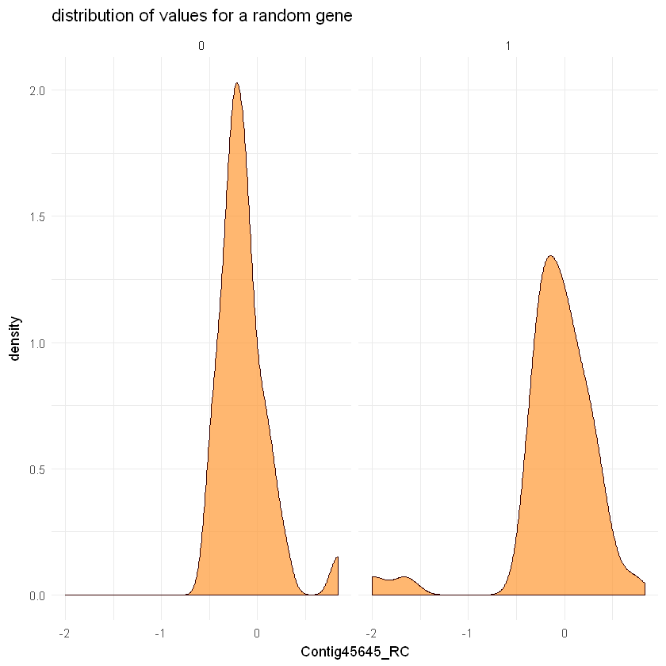

```r
library(ggplot2)
library(ggthemes)
ggplot(my_data,aes(Contig45645_RC))+
    geom_density(fill='#FF9933',colour='#330000',alpha=.7)+
    theme_minimal()+
    facet_wrap(~survival)+
    ggtitle('distribution of values for a random gene')
```

# Now we are ready to begin

```r
X<-my_data[,-24191]
y<-my_data[,24191]
```

Due to the volume of data, we have encountered problems in creating the design matrix and fitting it to RAM. To dribble them, we are using bigmemory package together with biglasso. The idea is based on using memory-mapped files to store the massive data on the disk, only loading data to memory when necessary during model fitting.

```r
library(bigmemory)
X.bm <- as.big.matrix(X)
```

Below we used parameter family='binomial' because of our bernoulli response variable-survival. Now, in order to screen variables we based our methodology on https://statweb.stanford.edu/~tibs/ftp/strong.pdf. Based on the paper, we can use a methodology called sequential strong rules that pinpoints variables that can be safely removed over a grid of tuning parameter values. Since during lasso methodology we have already computed the estimated parameters for each $\lambda$, the sequential strong rule discards the $j_{th}$ predictor from the optimization problem at $\lambda_k$ if $$|x_j^T(y-X\hat{\beta}(\lambda_k -1))|< 2 \lambda_k -\lambda_{k-1}.$$

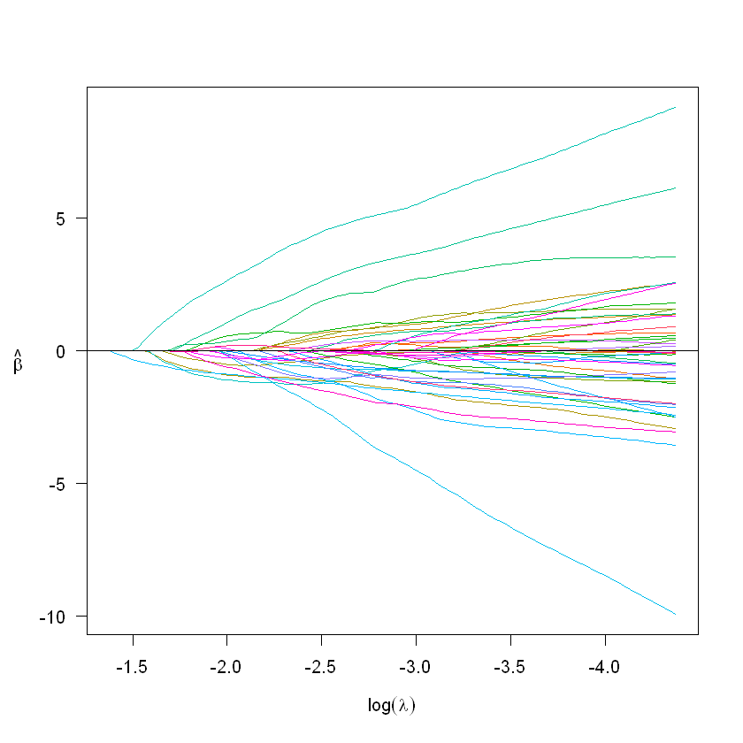

```r
library(biglasso)
screening <- biglasso(X.bm, y, screen = "SSR-Slores",family = 'binomial')
plot(screening)
```

```r
screening$safe_rejections
```

1. 13548

2. 13547

3. 13535

4. 13501

5. 13394

6. 13163

7. 12778

8. 12209

9. 11447

10. 10387

11. 9022

12. 7499

13. 5735

14. 3808

15. 1992

16. 753

17. 129

18. 0

19. 0

20. 0

21. 0

22. 0

23. 0

24. 0

25. 0

26. 0

27. 0

28. 0

29. 0

30. 0

31. 0

32. 0

33. 0

34. 0

35. 0

36. 0

37. 0

38. 0

39. 0

40. 0

41. 0

42. 0

43. 0

44. 0

45. 0

46. 0

47. 0

48. 0

49. 0

50. 0

51. 0

52. 0

53. 0

54. 0

55. 0

56. 0

57. 0

58. 0

59. 0

60. 0

61. 0

62. 0

63. 0

64. 0

65. 0

66. 0

67. 0

68. 0

69. 0

70. 0

71. 0

72. 0

73. 0

74. 0

75. 0

76. 0

77. 0

78. 0

79. 0

80. 0

81. 0

82. 0

83. 0

84. 0

85. 0

86. 0

87. 0

88. 0

89. 0

90. 0

91. 0

92. 0

93. 0

94. 0

95. 0

96. 0

97. 0

98. 0

99. 0

100. 0

The above object offers the number of variables that can be rejected for each $\lambda$, while col.idx return the variables that couldn't be rejected by the above SSR rule.

```r
cols_to_keep<-screening$col.idx
```

```r
head(cols_to_keep)
```

1. 4

2. 5

3. 6

4. 7

5. 9

6. 12

# Hypothesis testing- Significance analysis of microarrays

Now in order to perform randomization test, we also discard the other explanatory variables (age, ERP).

```r
screened_data<-my_data[,cols_to_keep]
X<-screened_data[,-13548]
```

Below we transform values of response variable, solely because it is required by the samr package.

```r
library(car)
Y<-recode(y,'0=1;1=2')
```

```r
length(colnames(X))
```

13547

```r
library(impute)
library(samr)
dataz=list(x=t(X),y=Y,
          geneid=1:13547,genenames=colnames(X),
          logged2=TRUE)
```

```r
samr.obj<-samr(dataz,  resp.type="Two class unpaired", nperms=4000)
delta.table <- samr.compute.delta.table(samr.obj)
```

[output not shown]

[output cut: 3997 more lines]

[output not shown]

```r
delta.table
```

| delta | # med false pos | 90th perc false pos | # called | median FDR | 90th perc FDR | cutlo | cuthi |
| --- | --- | --- | --- | --- | --- | --- | --- |
| 0.0000000000 | 1.044840e+04 | 1.052732e+04 | 13020 | 0.80248876 | 0.80855023 | -0.08413502 | 2.695960e-02 |
| 0.0006268198 | 1.044189e+04 | 1.052163e+04 | 13014 | 0.80235859 | 0.80848538 | -0.08547795 | 2.695960e-02 |
| 0.0025072791 | 1.040691e+04 | 1.049153e+04 | 12986 | 0.80139453 | 0.80791045 | -0.09213891 | 2.695960e-02 |
| 0.0056413781 | 1.034996e+04 | 1.044352e+04 | 12935 | 0.80015126 | 0.80738477 | -0.10312013 | 2.695960e-02 |
| 0.0100291166 | 1.028731e+04 | 1.038901e+04 | 12887 | 0.79827023 | 0.80616202 | -0.11532052 | 2.695960e-02 |
| 0.0156704946 | 1.012784e+04 | 1.025151e+04 | 12729 | 0.79565092 | 0.80536645 | -0.14628375 | 2.695960e-02 |
| 0.0225655123 | 9.918742e+03 | 1.006934e+04 | 12517 | 0.79242169 | 0.80445329 | -0.18756646 | 2.695960e-02 |
| 0.0307141695 | 9.537158e+03 | 9.739829e+03 | 12123 | 0.78669952 | 0.80341739 | -0.23705724 | 5.260664e-02 |
| 0.0401164663 | 9.138489e+03 | 9.392335e+03 | 11755 | 0.77741289 | 0.79900769 | -0.27212133 | 9.568931e-02 |
| 0.0507724026 | 8.691002e+03 | 8.997815e+03 | 11337 | 0.76660510 | 0.79366808 | -0.31675068 | 1.401752e-01 |
| 0.0626819785 | 8.039299e+03 | 8.432273e+03 | 10684 | 0.75246152 | 0.78924311 | -0.37585034 | 2.115388e-01 |
| 0.0758451940 | 7.312337e+03 | 7.792774e+03 | 9938 | 0.73579560 | 0.78413911 | -0.44386558 | 2.928758e-01 |
| 0.0902620491 | 6.602460e+03 | 7.153276e+03 | 9216 | 0.71641280 | 0.77618007 | -0.50872446 | 3.778086e-01 |
| 0.1059325437 | 5.831970e+03 | 6.453651e+03 | 8414 | 0.69312692 | 0.76701340 | -0.58855131 | 4.682179e-01 |
| 0.1228566779 | 5.190437e+03 | 5.871837e+03 | 7767 | 0.66826792 | 0.75599805 | -0.65845358 | 5.462411e-01 |
| 0.1410344517 | 4.577380e+03 | 5.294335e+03 | 7154 | 0.63983511 | 0.74005244 | -0.72909729 | 6.245989e-01 |
| 0.1604658651 | 3.947645e+03 | 4.701131e+03 | 6503 | 0.60704979 | 0.72291723 | -0.80263436 | 7.133822e-01 |
| 0.1811509180 | 3.342318e+03 | 4.104672e+03 | 5838 | 0.57251072 | 0.70309556 | -0.89764320 | 7.910011e-01 |
| 0.2030896105 | 2.690208e+03 | 3.449714e+03 | 5069 | 0.53071763 | 0.68055126 | -0.99896860 | 8.951267e-01 |
| 0.2262819426 | 2.263875e+03 | 2.998241e+03 | 4590 | 0.49321896 | 0.65321157 | -1.08953292 | 9.595357e-01 |
| 0.2507279142 | 1.758622e+03 | 2.440917e+03 | 3923 | 0.44828500 | 0.62220672 | -1.16756641 | 1.088013e+00 |
| 0.2764275254 | 1.354257e+03 | 1.982040e+03 | 3349 | 0.40437652 | 0.59183036 | -1.26610328 | 1.191733e+00 |
| 0.3033807762 | 1.052000e+03 | 1.619983e+03 | 2894 | 0.36351076 | 0.55977284 | -1.35734252 | 1.285491e+00 |
| 0.3315876665 | 7.737449e+02 | 1.262726e+03 | 2416 | 0.32025865 | 0.52265133 | -1.44713403 | 1.407110e+00 |
| 0.3610481964 | 5.849869e+02 | 1.009774e+03 | 2070 | 0.28260238 | 0.48781338 | -1.54425533 | 1.495057e+00 |
| 0.3917623659 | 3.889065e+02 | 7.233823e+02 | 1603 | 0.24261165 | 0.45126782 | -1.69303690 | 1.608848e+00 |
| 0.4237301750 | 2.709328e+02 | 5.428418e+02 | 1312 | 0.20650362 | 0.41375140 | -1.78076614 | 1.731121e+00 |
| 0.4569516236 | 1.911988e+02 | 4.093281e+02 | 1083 | 0.17654551 | 0.37795765 | -1.86882462 | 1.843970e+00 |
| 0.4914267118 | 1.049559e+02 | 2.490466e+02 | 742 | 0.14145004 | 0.33564231 | -2.02238150 | 2.017788e+00 |
| 0.5271554396 | 6.346173e+01 | 1.643496e+02 | 549 | 0.11559513 | 0.29936174 | -2.13188857 | 2.176091e+00 |
| 0.5641378069 | 3.173086e+01 | 9.519259e+01 | 356 | 0.08913164 | 0.26739491 | -2.33294988 | 2.312485e+00 |
| 0.6023738138 | 1.464501e+01 | 4.963032e+01 | 218 | 0.06717896 | 0.22766204 | -2.47138243 | 2.534923e+00 |
| 0.6418634603 | 8.136119e+00 | 3.010364e+01 | 159 | 0.05117056 | 0.18933106 | -2.60044328 | 2.671713e+00 |
| 0.6826067464 | 5.695283e+00 | 2.278113e+01 | 138 | 0.04127017 | 0.16508067 | -2.67857443 | 2.737527e+00 |
| 0.7246036720 | 8.136119e-01 | 3.254447e+00 | 28 | 0.02905757 | 0.11623027 | -3.05734200 | 3.531011e+00 |
| 0.7678542372 | 0.000000e+00 | 1.627224e+00 | 19 | 0.00000000 | 0.08564335 | -3.22790049 | 3.531011e+00 |
| 0.8123584420 | 0.000000e+00 | 1.627224e+00 | 15 | 0.00000000 | 0.10848158 | -3.33740478 | 3.531011e+00 |
| 0.8581162863 | 0.000000e+00 | 8.136119e-01 | 7 | 0.00000000 | 0.11623027 | -3.86546258 | 3.531011e+00 |
| 0.9051277702 | 0.000000e+00 | 0.000000e+00 | 2 | 0.00000000 | 0.00000000 | -3.86546258 | 1.000000e+10 |
| 0.9533928937 | 0.000000e+00 | 0.000000e+00 | 1 | 0.00000000 | 0.00000000 | -4.61856174 | 1.000000e+10 |
| 1.0029116567 | 0.000000e+00 | 0.000000e+00 | 1 | 0.00000000 | 0.00000000 | -4.61856174 | 1.000000e+10 |
| 1.0536840594 | 0.000000e+00 | 0.000000e+00 | 1 | 0.00000000 | 0.00000000 | -4.61856174 | 1.000000e+10 |
| 1.1057101015 | 0.000000e+00 | 0.000000e+00 | 1 | 0.00000000 | 0.00000000 | -4.61856174 | 1.000000e+10 |
| 1.1589897833 | 0.000000e+00 | 0.000000e+00 | 1 | 0.00000000 | 0.00000000 | -4.61856174 | 1.000000e+10 |
| 1.2135231046 | 0.000000e+00 | 0.000000e+00 | 1 | 0.00000000 | 0.00000000 | -4.61856174 | 1.000000e+10 |
| 1.2693100656 | 0.000000e+00 | 0.000000e+00 | 1 | 0.00000000 | 0.00000000 | -4.61856174 | 1.000000e+10 |
| 1.3263506660 | 0.000000e+00 | 0.000000e+00 | 1 | 0.00000000 | 0.00000000 | -4.61856174 | 1.000000e+10 |
| 1.3846449061 | 0.000000e+00 | 0.000000e+00 | 1 | 0.00000000 | 0.00000000 | -4.61856174 | 1.000000e+10 |
| 1.4441927857 | 0.000000e+00 | 0.000000e+00 | 1 | 0.00000000 | 0.00000000 | -4.61856174 | 1.000000e+10 |
| 1.5049943049 | 0.000000e+00 | 0.000000e+00 | 1 | 0.00000000 | 0.00000000 | -4.61856174 | 1.000000e+10 |

Among the things that are demonstrated above, we are most of all interested in median False Discovery Rate. We need to keep that metric low, since the scaling of this was the primary reason we turned away from the basic t-tests. Now we need to remember that for each of the hypothesis tests, we end up making a comparison between the mean difference of the 2 groups of the randomized samples and the initial difference before starting randomization. Depending on this, we end up rejecting the null hypothesis of the insignificance of the gene on survival or not. In order to decide for the rejection we need a threshold, above which we will reject the null hypothesis and declare the gene significant. We start by picking delta-threshold randomly.

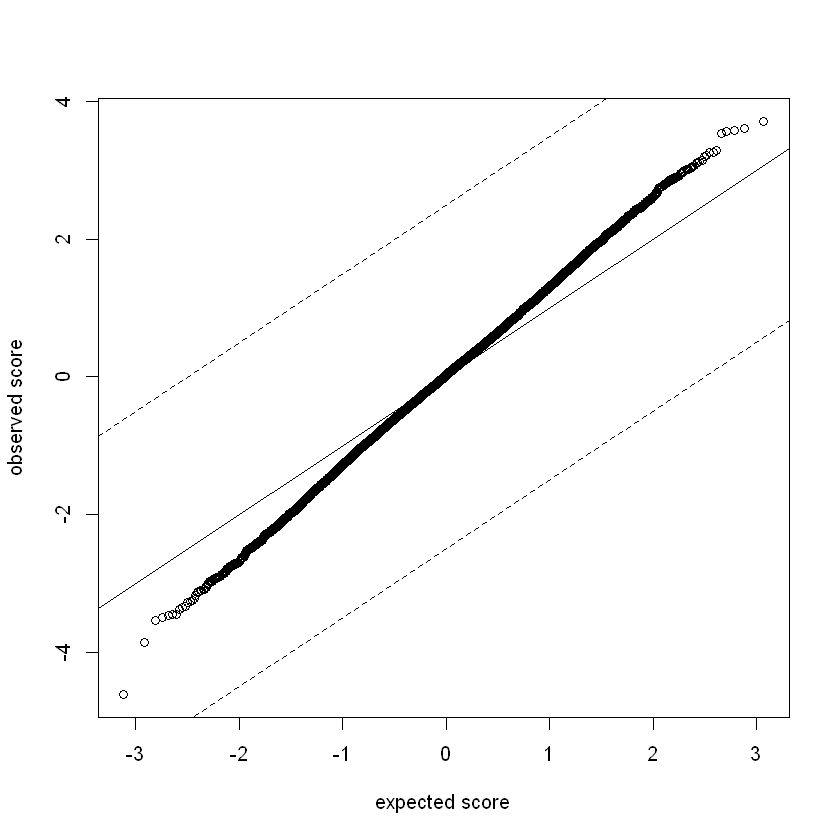

```r
delta=2.5
samr.plot(samr.obj,delta)
```

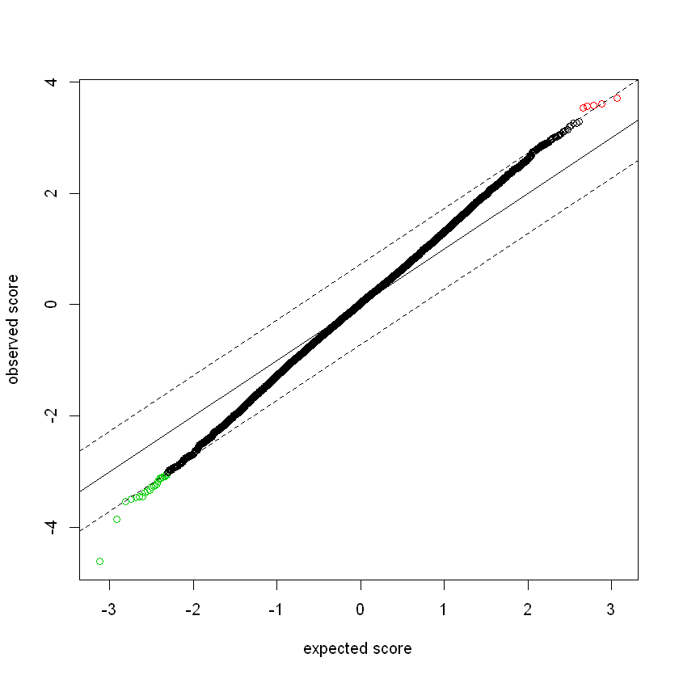

```r
delta=0.7246036720
samr.plot(samr.obj,delta)
```

```r
siggenes.table<-samr.compute.siggenes.table(samr.obj,delta, dataz,
                                            delta.table,all.genes=FALSE)
siggenes.table
```

```
$genes.up
     Row    Gene ID          Gene Name Score(d)           Numerator(r)
[1,] "5264" "Contig48328_RC" "5263"    "3.71340861437691" "0.463441176470588"
[2,] "5808" "NM_020974"      "5807"    "3.613822688778"   "0.486387700534759"
[3,] "4069" "NM_003862"      "4068"    "3.57974324635958" "0.313708556149733"
[4,] "7860" "Contig47405_RC" "7859"    "3.55953377918152" "0.46129679144385"
[5,] "9281" "AB037863"       "9280"    "3.53101125467717" "0.193576203208556"
     Denominator(s+s0)    Fold Change        q-value(%)
[1,] "0.124802095486158"  "1.37882673404043" "0"
[2,] "0.134590914503121"  "1.4009327479119"  "0"
[3,] "0.0876343733503117" "1.24289856127372" "0"
[4,] "0.129594722247564"  "1.37677880360498" "0"
[5,] "0.054821746306287"  "1.14359498876892" "0"

$genes.lo
```

[output cut: 81 more lines]

The last table offers information about the genes that have positive correlation with the outcome (genes.up) and the genes that have negative correlation with the outcome (genes.lo).

```r
siggenes.table$genes.up[,2]
```

1. 'Contig48328_RC'

2. 'NM_020974'

3. 'NM_003862'

4. 'Contig47405_RC'

5. 'AB037863'

```r
siggenes.table$genes.lo[,2]
```

1. 'AL080059'

2. 'NM_001216'

3. 'NM_016359'

4. 'NM_018265'

5. 'NM_016448'

6. 'Contig25991'

7. 'Contig46218_RC'

8. 'Contig55725_RC'

9. 'Contig28552_RC'

10. 'NM_004994'

11. 'NM_020120'

12. 'Contig54742_RC'

13. 'NM_006101'

14. 'Contig32185_RC'

15. 'NM_020123'

16. 'AA555029_RC'

17. 'NM_004701'

18. 'NM_003981'

19. 'NM_020132'

20. 'NM_018136'

21. 'Contig35251_RC'

22. 'NM_001168'

23. 'NM_013438'